# Áreas quemadas en el parque nacional José del Carmen Ramírez, marzo-abril 2023

José Ramón Martínez Batlle. Última actualización: 9 de abril de 2023

```r
# Paquetes
library(raster)
library(sf)
library(kableExtra)
library(tidyverse)
estilo_kable <- function(df, titulo = '', cubre_anchura = T) {
  df %>% kable(format = 'html', escape = F, booktabs = T, digits = 2, caption = titulo) %>%
  kable_styling(bootstrap_options = c("hover", "condensed"), full_width = cubre_anchura)
}

#Todo el parque. Límite mínimo del intervalo
dnbr <- raster('fuentes/dNBR-jose-del-carmen-ramirez-2023-masked-reclass-majority.tif')
esa <- raster('fuentes/esa-jose-del-carmen-ramirez-2023.tif')
dnbr <- resample(dnbr, esa)
dnbr[dnbr==0] <- NA
if(interactive()) plot(dnbr)
april_8 <- st_read('fuentes/mascara-quemado-inferido-imputado-from-landsat-april-8.gpkg', quiet = T)
dnbr_april8 <- rasterize(as(april_8, 'Spatial'), y = dnbr, field = 'DN', update = T)
if(interactive()) plot(dnbr_april8)
hotspots <- st_read('fuentes/mascara-quemado-inferido-imputado-from-hotspots.gpkg', quiet = T)
dnbr_april8_hotspots <- rasterize(as(hotspots, 'Spatial'),
                                  y = dnbr_april8, field = 'DN', update = T)
if(interactive()) plot(dnbr_april8_hotspots)
cross_tab_parque_min <- crosstab(dnbr_april8_hotspots, esa)
cross_tab_parque_min <- cross_tab_parque_min[2, 2:ncol(cross_tab_parque_min)]
names(cross_tab_parque_min) <- c("Trees", "Shrubland", "Grassland", "Cropland",
                      "Built-up", "Barren / sparse vegetation", "Open water")
cross_tab_parque_min <- cross_tab_parque_min[c("Trees", "Shrubland",
                                                 "Grassland", "Cropland")]
pct_parque_min <- round(prop.table(cross_tab_parque_min)*100, 2)
km2_parque_min <- cross_tab_parque_min * prod(res(dnbr_april8_hotspots))/1000000
total_km2_parque_min <- sum(km2_parque_min)

#Todo el parque. Límite máximo del intervalo
planet_april9 <- st_read('fuentes/mascara-quemado-inferido-imputado-from-planet-april-9.gpkg', quiet = T)
dnbr_april8_april9 <- rasterize(as(planet_april9, 'Spatial'),
                                  y = dnbr_april8, field = 'DN', update = T)
if(interactive()) plot(dnbr_april8_april9)
cross_tab_parque_max <- crosstab(dnbr_april8_april9, esa)
cross_tab_parque_max <- cross_tab_parque_max[2, 2:ncol(cross_tab_parque_max)]
names(cross_tab_parque_max) <- c("Trees", "Shrubland", "Grassland", "Cropland",
                      "Built-up", "Barren / sparse vegetation", "Open water")
cross_tab_parque_max <- cross_tab_parque_max[c("Trees", "Shrubland",
                                                 "Grassland", "Cropland")]
pct_parque_max <- round(prop.table(cross_tab_parque_max)*100, 2)
km2_parque_max <- cross_tab_parque_max * prod(res(dnbr_april8))/1000000
total_km2_parque_max <- sum(km2_parque_max)

#Área de alarma social (próxima al pico Duarte). Límite mínimo del intervalo
aoi <- st_read('fuentes/sector-norte-frontera-agropecuaria.gpkg', quiet = T)
dnbr_april8_hotspots_aoi <- mask(crop(dnbr_april8_hotspots, extent(aoi)), aoi)
esa_aoi <- mask(crop(esa, extent(aoi)), aoi)
cross_tab_aoi_min <- crosstab(dnbr_april8_hotspots_aoi, esa_aoi)
cross_tab_aoi_min <- cross_tab_aoi_min[, 2:4]
names(cross_tab_aoi_min) <- c("Trees", "Shrubland", "Grassland")
pct_aoi_min <- round(prop.table(cross_tab_aoi_min)*100, 2)
km2_aoi_min <- cross_tab_aoi_min * prod(res(dnbr_april8_hotspots_aoi))/1000000
total_km2_aoi_min <- sum(km2_aoi_min)

#Área de alarma social (próxima al pico Duarte). Límite máximo del intervalo
dnbr_april8_april9_aoi <- mask(crop(dnbr_april8_april9, extent(aoi)), aoi)
cross_tab_aoi_max <- crosstab(dnbr_april8_april9_aoi, esa_aoi)
cross_tab_aoi_max <- cross_tab_aoi_max[, 2:4]
names(cross_tab_aoi_max) <- c("Trees", "Shrubland", "Grassland")
pct_aoi_max <- round(prop.table(cross_tab_aoi_max)*100, 2)
km2_aoi_max <- cross_tab_aoi_max * prod(res(dnbr_april8_april9_aoi))/1000000
total_km2_aoi_max <- sum(km2_aoi_max)
```

> Contribuye a enmarcar adecuadamente la narrativa sobre este incendio. No se trata del “incendio del pico Duarte”, se trata de una desproporcionada actividad de quema DENTRO del parque nacional José del Carmen Ramírez, una de las áreas protegidas más afectadas en nuestro país por la agricultura migratoria y la agricultura de subsistencia.

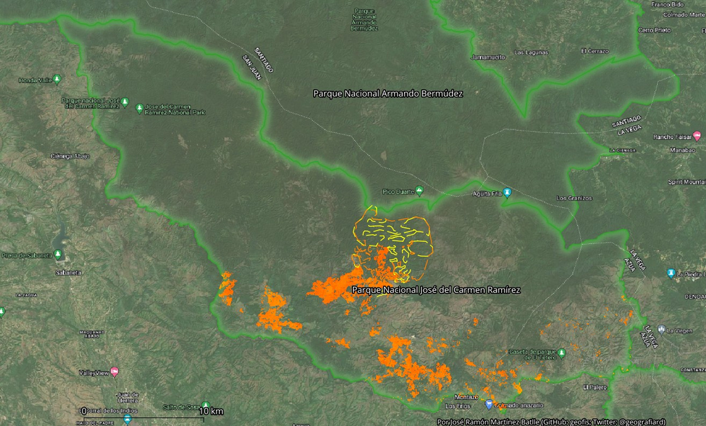

Áreas quemadas en el parque nacional José del Carmen Ramírez, marzo-abril de 2023

## Resultados

### El dato (en desarrollo)

Un incendio forestal que inició en marzo dentro del parque nacional José del Carmen Ramírez, cordillera Central de República Dominicana, quemó superficies considerables de bosque de pinar. El hecho de que algunos focos se acercaran al pico Duarte (máxima elevación del Caribe insular), popularizó este desafortunado episodio de la historia del parque.

Es probable que hayas llegado hasta aquí buscando “cuánto se quemó”, pues usamos las cifras para establecer comparaciones y, en definitiva, nos gustan los números. Pero no te quedes sólo con la cifra, pues este incendio visibiliza un problema aún más complejo: la intensa agricultura migratoria y de subsistencia dentro del área protegida.

> “A los mayores les gustan las cifras”. Antoine de Saint-Exupéry, *El principito*

¿Por qué es tan amplio el intervalo? Porque para obtenerlo por medio de imágenes satelitales que usan sensores ópticos, dependemos de que las nubes “nos dejen brechar” el terreno (los sensores SAR superan esta limitación, pero las imágenes gratuitas que usan esta tecnología, son poco frecuentes y más complejas de usar). De hecho, las estimaciones de superficie quemada realizadas en tierra, son más precisas en los primeros momentos del incendio, pero tan pronto se dispone de buenas escenas (sin nubes, y no mucho tiempo después de la fecha de extinción), las estimaciones por medio de imágenes satelitales suelen ser mejores.

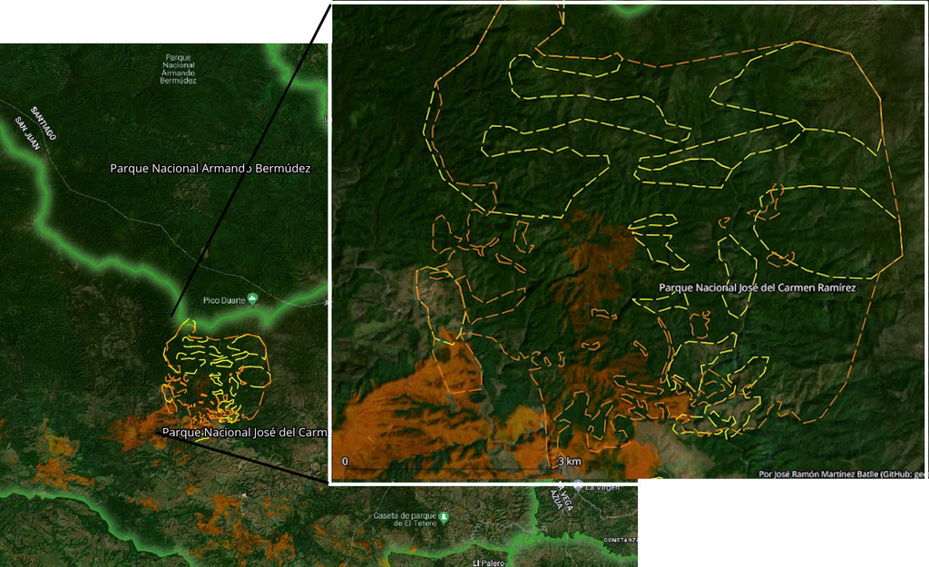

Áreas quemadas en el parque nacional José del Carmen Ramírez, marzo-abril de 2023. El detalle muestra amplía el borde norte que enlaza con el PN Armando Bermúdez. Los polígonos sombreados en naranja son áreas quemadas calculadas por el método dNBR, que ofrece una alta confiabilidad. Los polígonos de trazo discontinuo son áreas que se han imputado como quemadas. Los de trazo discontinuo amarillo proceden de interpretación visual de imagen Landsat 9 de 8 abril (confiable), y envolventes convexas de los puntos de calor / anomalías térmicas de FIRMS. El de trazo de discontinuo naranja, encierra parcialmente (con islas incluidas) la superficie visiblemente quemada en una imagen de Planet de 9 de abril de 2023.

No nos hemos “sentado” a tener una discusión a nivel de país sobre muchas de nuestras áreas protegidas, pero esta es la norma respecto del conjunto del sistema: hemos discutido poco. Es relevante que ni tan siquiera las áreas más carismáticas, como Los Haitises, sierra de Bahoruco o Valle Nuevo, han podido salir de este círculo de degradación ambiental. De éstas últimas se habla, “salen” en los medios, pero el parque nacional José del Carmen Ramírez “no suena”.

Hay algunas señales preocupantes sobre lo que está ocurriendo en el parque nacional José del Carmen Ramírez. Año tras año, la frontera agrícola avanza más y más hacia el norte y al oeste, que son los únicos cuadrantes todavía con bosque del área protegida. En concreto, en la loma El Picacho (oeste del parque) un incendio consumió varias hectáreas de bosque.

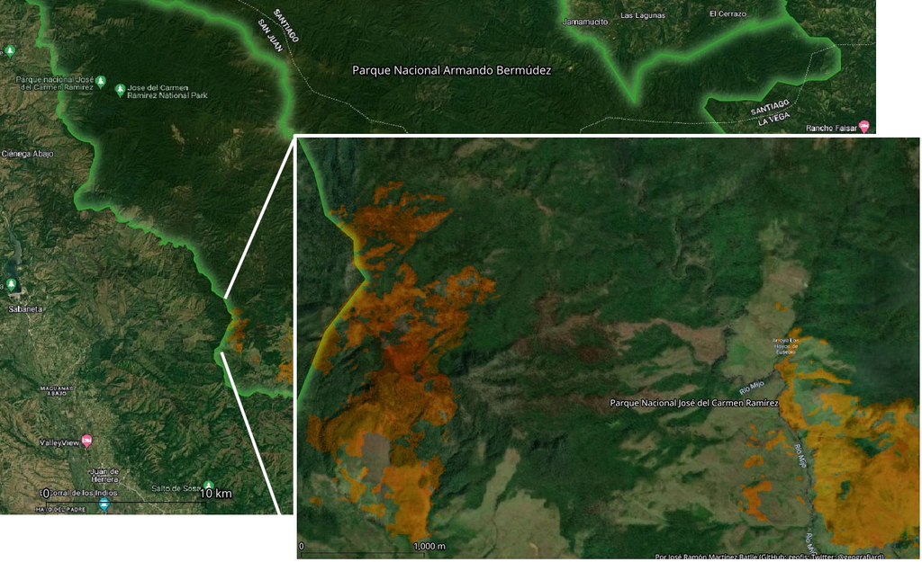

Áreas de bosque afectadas por fuego en la loma el Picacho

Si buscas la importancia de esta área protegida, encontrarás referencias sobre su papel en la captación de agua, o sobre su destacada biodiversidad. Sin embargo, te lo voy a poner fácil: sin José del Carmen Ramírez no habría Armando Bermúdez y, sin este último, “se pué cuidá el Cibao (y to’ el país)”. No perdamos el foco, esto es serio, el país necesita una discusión profunda sobre el presente y el futuro de este parque nacional.

## Método

### Obtención de los intervalos

Usé escenas Sentinel 2 para caracterizar la superficie quemada durante todo el mes de marzo y parte de abril. La fuente prefuego fue una composición promediada de escenas 22/02/2023 y 27/02/2023; la fuente posfuego fue una única escena, de fecha 3/04/2023. Para extraer la superficie quemada, apliqué una versión modificada del [*script* Google Earth Engine de UN-Spider “BURN SEVERITY MAPPING USING THE NORMALIZED BURN RATIO (NBR)”](https://un-spider.org/advisory-support/recommended-practices/recommended-practice-burn-severity/burn-severity-earth-engine), que consiste en calcular la severidad de quemado usando el diferencial del índice normalizado de quema (dNBR). Este método ofrece el cálculo más consistente y preciso de superficie quemada disponible actualmente. A esta superficie le imputé áreas quemadas adicionales extraídas desde otras fuentes para construir los límites inferior y superior del intervalo, respectivamente.

Para obtener el límite inferior agregué, al cómputo base, áreas interpretadas como quemadas por medio de inspección visual de la escena Landsat 9 adquirida el 8/04/2023 (ID: LC09_L1TP_008047_20230408_20230408_02_T1). También agregué las envolventes convexas de los puntos de calor / anomalías térmicas de FIRMS correspondientes a los 7 días anteriores al 8/04/2023. Por otra parte, para obtener el límite superior del intervalo agregué, al computo base, áreas quemadas interpretadas como tal por medio de inspección visual de escenas Planet de 9 de abril (ID: 20230409_142601_27_24b9 y 20230409_142603_61_24b9).

En futuras entregas, en la medida en la que nuevas escenas se hagan disponibles, aplicaré el método dNBR de forma consistente a toda el área protegida para obtener un cómputo fiable. De esta manera, encogeré la anchura del intervalo en próximas actualizaciones. “Mantengan la sintonía”.

### La cobertura “bosque”

La superficie de bosque, que se trata sobre todo de pinar, parte del dato ofrecido por la ESA (Zanaga, Daniele et al. 2022). Realicé un simple chequeo cruzado de esta fuente, y noté un error muy común en estas clasificaciones: las áreas situadas en sombra de relieve, sobre todo en contextos muy intervenidos o de cobertura variable, suelen aparecer clasificadas como bosque cuando probablemente son sólo pastizales o matorrales. Es decir, en general, la cobertura “*tree cover*” de Zanaga, Daniele et al. (2022) está sobrestimada en áreas intervenidas. Una alternativa sería usar la capa de cobertura forestal dominicana del estudio de 2019, siempre que esté disponible sin previa petición, que no es el caso (ya estoy muy viejo para estar escribiendo la típica carta). Hay más alternativas, como [Copernicus Global Land Cover Layers](https://developers.google.com/earth-engine/datasets/catalog/COPERNICUS_Landcover_100m_Proba-V-C3_Global) o [Hansen Global Forest Change v1.9 (2000-2021)](https://developers.google.com/earth-engine/datasets/catalog/UMD_hansen_global_forest_change_2021_v1_9), pero no encontraremos grandes diferencias, al menos en la parte más boscosa del parque. No obstante, la fuente suele ser consistente en áreas donde el bosque es generalizado, lo cual en el parque nacional José del Carmen Ramírez, ocurre hacia el norte y al noroeste.

## Referencias

Zanaga, Daniele, Van De Kerchove, Ruben, Daems, Dirk, De Keersmaecker, Wanda, Brockmann, Carsten, Kirches, Grit, Wevers, Jan, et al. 2022. “ESA WorldCover 10 m 2021 V200,” October. https://doi.org/10.5281/ZENODO.7254221.